# Demographic estimates from age data

Malavika Rajeev

12/9/2020

## Age data

I have this age data from campaigns from 2018 & 2019 for doggoes in Moramanga District:

```r
# Age pyramid
animals_age <- read_csv("animals_age.csv")
animals_age %>%
  mutate(Sex = toupper(Sex), age = floor(age_mos/12)) %>%
  group_by(Sex, age) %>%
  summarize(N  = n()) %>%
  mutate(N = ifelse(Sex == "M", -N, N)) -> age_pyramid
```

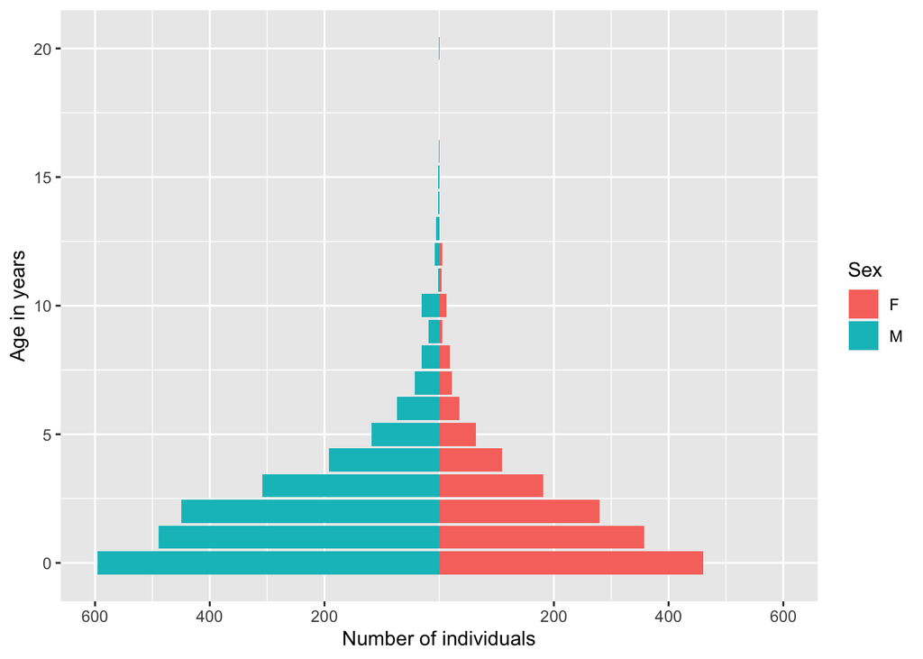

```r
ggplot(age_pyramid, aes(x = age, y = N, fill = Sex)) +
  geom_col() +
  scale_y_continuous(breaks = c(seq(-600, -200, 200), seq(200, 600, 200)),
                     labels = c(seq(600, 200, -200), seq(200, 600, 200)),
                     limits = c(-600, 600)) +
  coord_flip() +
  labs(x = "Age in years", y = "Number of individuals")
```

Looks like fast growing & slightly sex biased population (standard free-roaming dog pop characteristics)

## Annie’s thesis

I pulled from Annie’s thesis to estimate growth/survival. Jess’s original code:

```r
age_pyramid %>%
  filter(!is.na(age) & !is.na(N)) %>%
  mutate(age_class = case_when(age == 0 ~ 0, # < 1 yr olds
                               age == 1 ~ 1, # 1 - 2 yr olds
                               age > 1 & age < 5 ~ 2, # 2 - 5 yr olds
                               age >= 5 ~ 3)) %>% # 5+ yr olds
  group_by(age_class) %>%
  summarize(N = sum(abs(N))) %>%
  mutate(prop = N/sum(N)) -> n_by_age
```

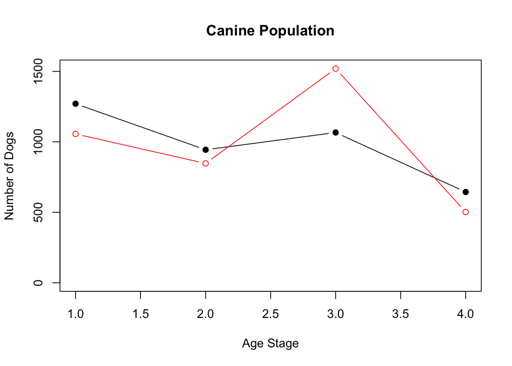

```r
# Original model from Annie's thesis
SS <- function(par, number.individuals) {
  ## put chosen parameters into the matrix; and use exponential to
  # ensure doesnt go negative
  psurv <- exp(par[1:2])/(1+exp(par[1:2]))
  ## make the matrix with this value of psurv
  mat1 <- matrix(0,4,4)
  mat1[1,1] <- psurv[1]*0 ## after one year, no one stays a baby
  mat1[2,1] <- psurv[1]*1 ## every baby becomes juvenile
  mat1[2,2] <- psurv[2]*0 ## no one stays a juvenile
  mat1[3,2] <- psurv[2]*1 ## every juvenile becomes adult
  mat1[3,3] <- psurv[2]*(1-1/3) ## 1-1/3 of them stay in that age
  class
  mat1[4,3] <- psurv[2]*1/3 ## 1/3 of them age up
  mat1[4,4] <- psurv[2] ## surviving
  ## add in the fertility
  ## xxj note I've added another value - so I've said that in column 3,
  # we have exp(par[3])*1,
  ### and in column 4 we have exp(par[3])*a probabilty defined by
  # par[4]. This is so it has to be smaller!
    mat1[1,3:4] <- 1+exp(par[c(3)])*c(1,exp(par[4])/(1+exp(par[4])))
  ## calculate what this does to the stable structure
  prop.stable.struct.after.seed1 <-
    Re(eigen(mat1)$vector[1:4,1])/sum(Re(eigen(mat1)$vector[1:4,1]))
  ## get the sum of squares (measure of distance between observed and
  # predicted, which we want to be as small as possible)
  sum.of.squares <- sum((number.individuals[1:4]-
                         prop.stable.struct.after.seed1*sum(number.individuals,na.rm=TRUE))^2)
  ## put it back
  return(sum.of.squares)
}

tmp <- optim(par=c(-0.5, -0.5, log(2.5), log(2.5)), fn = SS,
             number.individuals = n_by_age$N)

## build matrix and predictions with these optimal results
psurv <- exp(tmp$par[1:2])/(1+exp(tmp$par[1:2]))

## make the matrix with this value of psurv
mat1 <- matrix(0,4,4)
mat1[2,1] <- psurv[1]*1 ## every baby becomes juvenile
mat1[3,2] <- psurv[2]*1 ## every juvenile becomes adult
mat1[3,3] <- psurv[2]*(1-1/3) ## 1-1/3 of them stay in that age class
mat1[4,3] <- psurv[2]*1/3 ## 1/3 of them age up
mat1[4,4] <- psurv[2] ## surviving
p.reduce.fert.old <- exp(tmp$par[4])/(1+exp(tmp$par[4]))
mat1[1,3:4] <- 1+exp(tmp$par[3])*c(1,p.reduce.fert.old)

## predict the size distribution
optim.prop.stable.struct.after.seed <-
  Re(eigen(mat1)$vector[1:4,1])/Re(sum(eigen(mat1)$vector[1:4,1]))

## and add this one to the plot from before
plot(1:4, optim.prop.stable.struct.after.seed*sum(n_by_age$N, na.rm=TRUE),
     type = "b", pch=19,
     xlab="Age Stage", ylab="Number of Dogs", main="Canine Population",
     ylim=range(c(0, n_by_age$N), na.rm=TRUE)) # predicted
points(1:4, n_by_age$N[1:4], type="b", col="red") # observed
```

```r
## and this means, now you can figure out what the population growth
Re(eigen(mat1)$value[1]) # growth rate = 1.35
```

```
## [1] 1.346079
```

## Adapted

I adapted it to try and estimate pup survival and adult survival, and changed it so that all dogs > 12 mos. reproduce and fertility doesn’t decline (which we think is how it works (ish) for dogs).

In this case, should fertility be something like avg. litter size * avg. # of litters per yr * proportion pop female? Am I getting these units right?

```r
agemod1 <- function(par = c(psurv_pup = -1,
                            psurv_adult = -1),
                    fert = 3,
                    n_per_age, type = "fit") {

  list2env(as.list(par), envir = environment())

  # transform parameters to [0, 1]
  p1 <- exp(psurv_pup)/(1 + exp(psurv_pup))
  p2 <- exp(psurv_adult)/(1 + exp(psurv_adult))

  # make the Leslie matrix
  lmat <- matrix(0, 4, 4)
  lmat[2, 1] <- p2 # every surviving baby becomes juvenile
  lmat[3, 2] <- p2 # every surviving juvenile becomes adult
  lmat[3, 3] <- p2 * 2/3 # 2/3 of them stay in this age class (for years 1 & 2 in age bin)
  lmat[4 ,3] <- p2 * 1/3 # 1/3 of them age up (after year 3 in age bin)
  lmat[4, 4] <- p2  # surviving of final age class

  # add in the fertility (same for all adults, i.e. excluding puppies)
  # this is pup survival * birthrate which is not actually identifiable
  # so we look at an average litter size of fert & try and estimate pup survival
  lmat[1, 2:4] <- fert * p1

  # calculate what this does to the stable structure
  prop_stable <- Re(eigen(lmat)$vector[1:4, 1]) / sum(Re(eigen(lmat)$vector[1:4, 1]))

  if(type == "pred") {
    # predicted stable age
    stable_age <- prop_stable*sum(n_per_age)
    growth <- Re(eigen(lmat)$value[1])
    return(list(stable_age = stable_age, growth = growth))
  }

  if(type == "fit") {
    # get the sum of squares (distance between observed and predicted prop in each age class)
    sum_of_squares <- sum((n_per_age - prop_stable*sum(n_per_age))^2)
    return(sum_of_squares)
  }
}

exp_trans <- function(x) exp(x)/(1 + exp(x))

age_ests <- optim(par = list(psurv_pup = -1, psurv_adult = 1),
                  fert = 4,
                  fn = agemod1, n_per_age = n_by_age$N)
exp_trans(age_ests$par)
```

```
##   psurv_pup psurv_adult
##   0.1440329   0.8578712
```

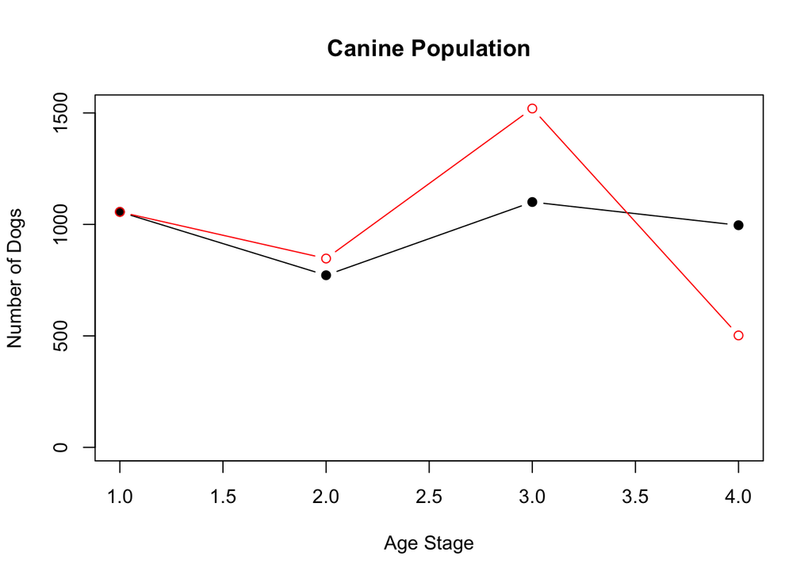

```r
preds <- agemod1(n_per_age = n_by_age$N, par = age_ests$par, type = "pred")
plot(1:4, preds$stable_age,
     type = "b", pch = 19,
     xlab = "Age Stage", ylab = "Number of Dogs", main = "Canine Population",
     ylim = range(c(0, n_by_age$N, preds$stable_age))) # predicted
points(1:4, n_by_age$N[1:4], type="b", col="red") # observed
```

```r
preds$growth
```

```
## [1] 1.173698
```

## Sensitivity to initial parameter values

Optim estimates are highly dependent on starting values:

```r
age_ests <- optim(par = list(psurv_pup = -1, psurv_adult = -1),
                  fert = 4,
                  fn = agemod1, n_per_age = n_by_age$N)
exp_trans(age_ests$par)
```

```
##   psurv_pup psurv_adult
##  0.08926205  0.53163066
```

```r
preds <- agemod1(n_per_age = n_by_age$N, par = age_ests$par, type = "pred")
preds$growth
```

```
## [1] 0.7273574
```

```r
age_ests <- optim(par = list(psurv_pup = -0.5, psurv_adult = -0.5),
                  fert = 4,
                  fn = agemod1, n_per_age = n_by_age$N)
preds <- agemod1(n_per_age = n_by_age$N, par = age_ests$par, type = "pred")
exp_trans(age_ests$par)
```

```
##   psurv_pup psurv_adult
##   0.1166163   0.6946043
```

```r
preds$growth
```

```
## [1] 0.9503157
```

```r
age_ests <- optim(par = list(psurv_pup = 1, psurv_adult = 1),
                  fert = 4,
                  fn = agemod1, n_per_age = n_by_age$N)
preds <- agemod1(n_per_age = n_by_age$N, par = age_ests$par, type = "pred")
exp_trans(age_ests$par)
```

```
##   psurv_pup psurv_adult
##   0.1620270   0.9651166
```

```r
preds$growth
```

```
## [1] 1.320405
```

## Brute force

But if you brute force it, and just get SS across par values, then there’s a ridge along low pup survival vs. higher adult survival (which I guess makes sense), and intermediate growth ( 1 - 1.5 %):

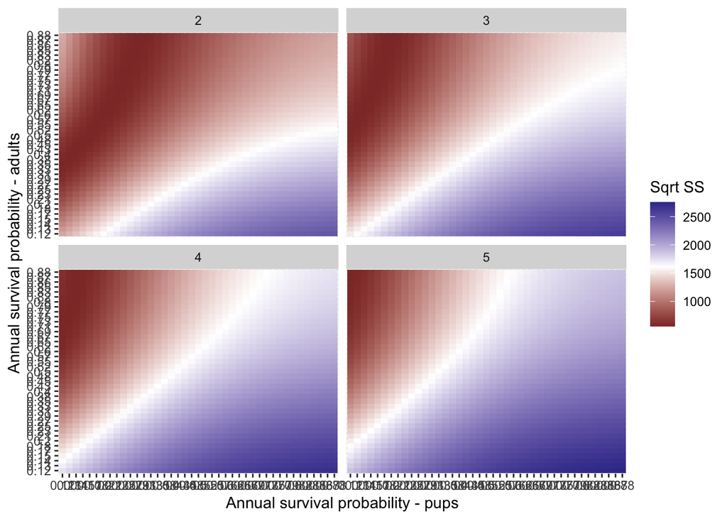

```r
ll_grid <- expand.grid(psurv_pup = seq(-2, 2, by = 0.1),
                       psurv_adult = seq(-2, 2, by = 0.1),
                       fert = seq(2, 5, by = 1))
ll_grid %>%
  rowwise() %>%
  mutate(ss = agemod1(n_per_age = n_by_age$N,
                      par = c(psurv_pup = psurv_pup,
                              psurv_adult = psurv_adult),
                      fert = fert, type = "fit"),
         gr = agemod1(n_per_age = n_by_age$N,
                      par = c(psurv_pup = psurv_pup,
                              psurv_adult = psurv_adult),
                      fert = fert, type = "pred")$growth) -> ll

ggplot(data = ll) +
  geom_tile(aes(x = factor(round(exp_trans(psurv_pup), 2)),
                y = factor(round(exp_trans(psurv_adult), 2)),
                fill = sqrt(ss))) +
  facet_wrap(~ fert) +
  scale_fill_gradient2(midpoint = median(sqrt(ll$ss)), name = "Sqrt SS") +
  labs(x = "Annual survival probability - pups",
       y = "Annual survival probability - adults")
```

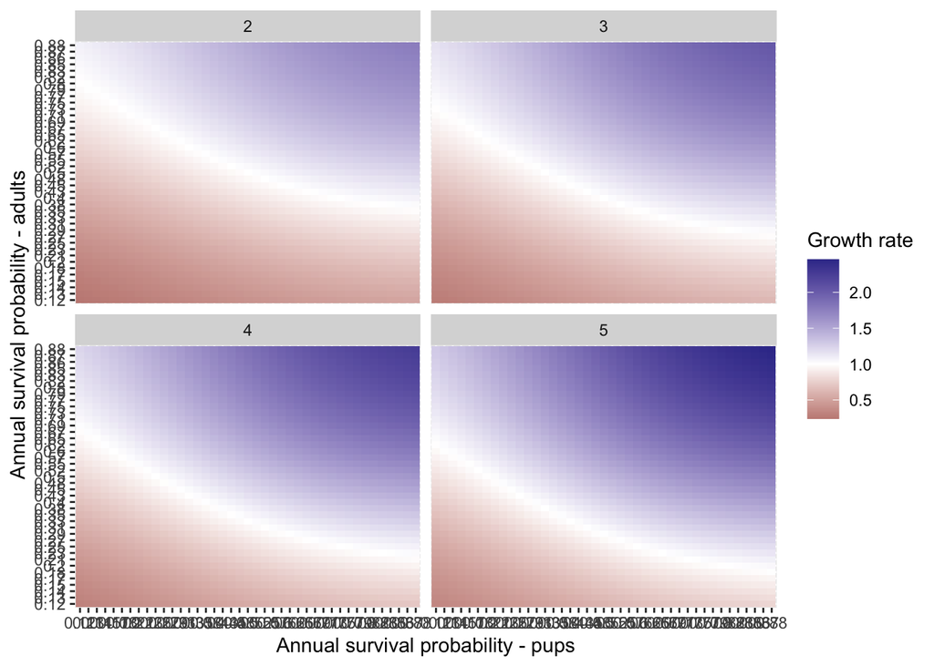

```r
ggplot(data = ll) +
  geom_tile(aes(x = factor(round(exp_trans(psurv_pup), 2)),
                y = factor(round(exp_trans(psurv_adult), 2)),
                fill = gr)) +
  facet_wrap(~ fert) +
  scale_fill_gradient2(midpoint = 1, name = "Growth rate") +
  labs(x = "Annual survival probability - pups",
       y = "Annual survival probability - adults")
```

**How to present results? Use initial vals with lowest from brute forcing?** **Am I just asking too much from this data? I guess just fitting to four vals that could be explained by lots of combos of pars?**

## Vax model

Discrete time approximation:

- Three years of vaccine immunity (discrete)
- Different pup vs. adult survival
- Different campaign strategies
  - Campaign style (annual, target dogs of all ages, what we did in 2018)
  - Puppy vaccination, continiously target newborn pups
  - Combined strategies

```r
# Need to track down a revaccination issue in this but approximately right
simvacc <- function(tmax, pup_surv, adult_surv, revacc, pup_cov,
                    campaign_cov, campaign_times, pup_month_vacc = 1,
                    birthrate, S_adult_0, V_adult_0,
                    V_pup_0, S_pup_0) {

  # Set-up
  V_adult <- matrix(0, nrow = 36, ncol = tmax)
  S_adult <- rep(0, tmax)
  V_pup <- S_pup <- matrix(0, nrow = 12, ncol = tmax)

  # Initalize
  S_adult[1] <- S_adult_0
  V_adult[1, 1] <- V_adult_0
  V_pup[, 1] <- V_pup_0
  S_pup[, 1] <- S_pup_0

  for(t in 2:tmax) {

    # Births (everyone first has babies and then dies)
    births <- birthrate * (sum(V_adult[1:36, t - 1]) + S_adult[t - 1])

    # balance births (all to susceptibles)
    S_pup[1, t] <- births # get replaced

    # Pup mortality
    S_pup[2:12, t] <- S_pup[1:11, t - 1] * pup_surv
    V_pup[2:12, t] <- V_pup[1:11, t - 1] * pup_surv

    # Balance the adults (ageing in 12 mo old pups)
    S_adult[t] <- adult_surv * S_adult[t - 1] + pup_surv * S_pup[12, t - 1]

    # pups to vaccinate (at age x)
    pups_to_vacc <- ifelse(pup_month_vacc > 1, S_pup[pup_month_vacc, t],
                           births)

    # do puppy vaccination
    V_pup[pup_month_vacc, t] <- pups_to_vacc * pup_cov
    S_pup[pup_month_vacc, t] <- S_pup[pup_month_vacc, t] - pups_to_vacc * pup_cov

    # Do the waning (adults only!)
    V_adult[2:36, t] <- adult_surv * V_adult[1:35, t - 1]
    S_adult[t] <- S_adult[t] + V_adult[36, t - 1]

    # Vaccinate as part of campaign accounting for revax
    cov_now <- ifelse(t %in% campaign_times, campaign_cov, 0)
    camp_vacc_adult <- (S_adult[t] + revacc * sum(V_adult[, t])) * cov_now - revacc * sum(V_adult[, t])
    camp_vacc_adult <- ifelse(camp_vacc_adult < 0, 0, camp_vacc_adult)

    # every vax is revaccinated with a certain revacc prob
    if(camp_vacc_adult > 0) {
      V_adult[1, t] <- camp_vacc_adult + revacc * sum(V_adult[, t])
      V_adult[2:36, t] <- (1 - revacc) * V_adult[2:36, t]
    } else {
      V_adult[1, t] <- camp_vacc_adult # newly vaccinated
    }

    # Balance addtl campaign vax adults
    S_adult[t] <- S_adult[t] - camp_vacc_adult

    # Balance addtl campaign vax pups (assuming that no puppies are revax)
    camp_vacc_pup <- S_pup[pup_month_vacc:12, t] * cov_now
    V_pup[pup_month_vacc:12, t] <- V_pup[pup_month_vacc:12, t] + camp_vacc_pup
    S_pup[pup_month_vacc:12, t] <- S_pup[pup_month_vacc:12, t] - camp_vacc_pup

    # Add in surviving pups aging to adults so that they can wane appropriately
    t_to_sub <- pup_month_vacc - 1
    V_adult[13 - t_to_sub, t] <- V_adult[13, t] +  pup_surv * V_pup[12, t - 1]

  }

  V <- colSums(V_pup) + colSums(V_adult)
  S <- colSums(S_pup) + S_adult

  return(list(S = S, V = V, V_adult = V_adult, V_pup = V_pup,
              S_adult = S_adult, S_pup = S_pup))

}
```

### Comparing campaigns vs. continuous pup vax

```r
age_ests <- optim(par = list(psurv_pup = -1, psurv_adult = 1),
                  fert = 3,
                  fn = agemod1, n_per_age = n_by_age$N)
preds <- agemod1(n_per_age = n_by_age$N, par = age_ests$par, type = "pred")
exp_trans(age_ests$par)
```

```
##   psurv_pup psurv_adult
##   0.1827973   0.8165675
```

```r
preds$growth
```

```
## [1] 1.192181
```

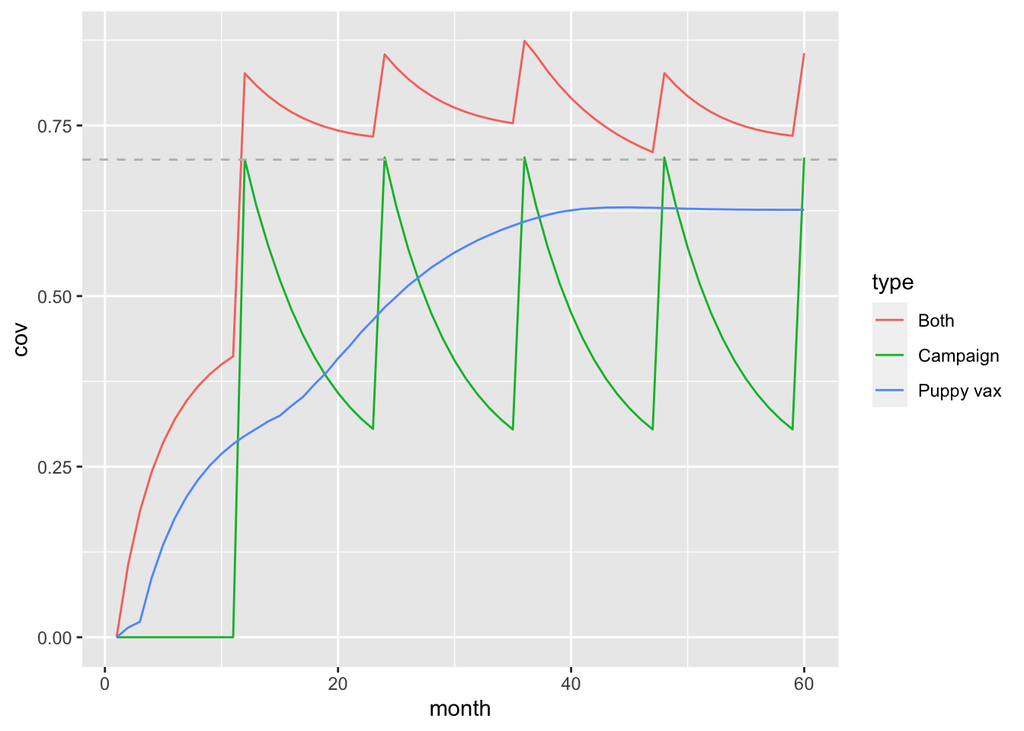

```r
# annual survival probability to monthly
surv <- as.list(exp_trans(age_ests$par)^(1/12))

# proportion adults
prop <- preds$stable_age/(sum(preds$stable_age))
prop_adults <- 1 - prop[1]

# for population of 1000
# with campaigns only
camp <- simvacc(tmax = 12*5, pup_surv = surv$psurv_pup, adult_surv = surv$psurv_adult,
        revacc = 1,
        pup_cov = 0,
        campaign_cov = 0.7, campaign_times = seq(12, 12*5, by = 12),
        pup_month_vacc = 1,
        birthrate = 3/12, # monthly birth rate
        S_adult_0 = prop_adults*1000,
        S_pup_0 = rep(prop[1]/12, 12)*1000, V_adult_0 = 0,
        V_pup_0 = rep(0, 12))

# with pup vacc only
pup <- simvacc(tmax = 12*5, pup_surv = surv$psurv_pup, adult_surv = surv$psurv_adult,
        revacc = 1,
        pup_cov = 0.7,
        campaign_cov = 0, campaign_times = 0,
        pup_month_vacc = 3,
        birthrate = 3/12, # monthly birth rate
        S_adult_0 = prop_adults*1000,
        S_pup_0 = rep(prop[1]/12, 12)*1000, V_adult_0 = 0,
        V_pup_0 = rep(0, 12))

both <- simvacc(tmax = 12*5, pup_surv = surv$psurv_pup, adult_surv = surv$psurv_adult,
        revacc = 1,
        pup_cov = 0.7,
        campaign_cov = 0.7, campaign_times = seq(12, 12*5, by = 12),
        pup_month_vacc = 1,
        birthrate = 3/12, # monthly birth rate
        S_adult_0 = prop_adults*1000,
        S_pup_0 = rep(prop[1]/12, 12)*1000, V_adult_0 = 0,
        V_pup_0 = rep(0, 12))

vacc_comp <- bind_rows(tibble(month = 1:60,
                              cov = camp$V/(camp$S + camp$V), type = "Campaign"),
                       tibble(month = 1:60,
                              cov = pup$V/(pup$S + pup$V), type = "Puppy vax"),
                       tibble(month = 1:60,
                              cov = both$V/(both$S + both$V), type = "Both"))

ggplot(vacc_comp) +
  geom_line(aes(x = month, y = cov, color = type)) +
  geom_hline(yintercept = 0.7, linetype = 2, color = "grey")
```